# Telegram Bot для рекомендации настольных игр

### Архитектура приложения

Используем телеграм-бота, пользователь вводит название игры, а телеграм-бот обращается к функции рекомендации игр. Эта функция обращается к уже созданной рекомендательной системе, и на ее основе выдает рекомендации настольных игр, которые бот отображает в чате. Функция может работать в двух режимах: выдача рекомендаций на основе игры, которая нравится пользователю или выдача рандомной игры. Также есть функция для получения информации об игре из датасета, к ней тоже обращается телеграм-бот для вывода характеристик о рандомной игре. Таким образом, бот лишь передает в функцию название выбранной пользователем игры, остальное обрабатывается внутри самой функции рекомендации игры. Данные о рекомендациях не сохраняются.

```r
#Функция для ввода данных
board_games_rec <- as.data.frame(board_games_rec)
user_input = function(gamename,data = board_games_rec){

    selectedgame <- board_games_rec[which(board_games_rec$name %in% gamename),2]
    selectedgame <- as.data.frame(selectedgame)
    selectedgame$id <- selectedgame$selectedgame
    selectedgame <- selectedgame %>% select(id)
    return(selectedgame)


}
```

```r
#Далее просто заворачиваем всё в функцию
#На входе у неё есть параметр option: 1)recommend основывает на различиях между играми, 2)random выдает случайную игру. Вариант с фильтрацией данных ниже отдельной функцией


board_games_rec$id = as.character(board_games_rec$id)

recomendar = function(selected_game, dissimilarity_matrix,
                      games, n_recommendations = 5, option){

  if(option == "recommend"){

  selected_game_indexes = which(colnames(dissimilarity_matrix) %in% selected_game$id)


  results = data.frame(dissimilarity=dissimilarity_matrix[, selected_game_indexes],
                       recommended_game = row.names(dissimilarity_matrix),
                       stringsAsFactors = FALSE)


  recommendations = results %>% mutate(similarity = 1-dissimilarity)
  recommendations = recommendations[order(-recommendations$similarity),]
  recommendations = recommendations$recommended_game[2:(n_recommendations+1)]
  #recommendations = filter(games, as.character(id) %in% recommendations)
  recommendations = games[games$id %in% recommendations,]
  recommendations = recommendations %>% select(name)


  return(recommendations)}

  else if (option == "random"){

    return(games[runif(1,min = 1, max = length(games)),1])
    }

}
```

```r
get_info = function(selected_games) {
  info=board_games_clean %>% filter(name %in% selected_games) %>% select(average_rating,category1,mechanics1,average_playtime)

  return(info)
}
```

````r
library(purrr)
library(tidyr)
library(stringr)

# функция для перевода data.frame в telegram таблицу
to_tg_table <- function( table, align = NULL, indents = 3, parse_mode = 'Markdown' ) {

  # если выравнивание не задано то выравниваем по левому краю
  if ( is.null(align) ) {

    col_num <- length(table)
    align   <- str_c( rep('l', col_num), collapse = '' )

  }

  # проверяем правильно ли заданно выравнивание
  if ( length(table) != nchar(align) ) {

    align <- NULL

  }

  # новое выравнивание столбцов
  side <- sapply(1:nchar(align),
         function(x) {
           letter <- substr(align, x, x)
           switch (letter,
                   'l' = 'right',
                   'r' = 'left',
                   'c' = 'both',
                   'left'
           )
  })

  # сохраняем имена
  t_names      <- names(table)

  # вычисляем ширину столбцов
  names_length <- sapply(t_names, nchar)
  value_length <- sapply(table, function(x) max(nchar(as.character(x))))
  max_length   <- ifelse(value_length > names_length, value_length, names_length)

  # подгоняем размер имён столбцов под их ширину + указанное в indents к-во пробелов
  t_names <- mapply(str_pad,
                    string = t_names,
                    width  = max_length + indents,
                    side   = side)

  # объединяем названия столбцов
  str_names <- str_c(t_names, collapse = '')

  # аргументы для фукнции str_pad
  rules <- list(string = table, width = max_length + indents, side = side)

  # поочереди переводим каждый столбец к нужному виду
  t_str <-   pmap_df( rules, str_pad )%>%
              unite("data", everything(), remove = TRUE, sep = '') %>%
              unlist(data) %>%
              str_c(collapse = '\n')

  # если таблица занимает более 4096 символов обрезаем её
  if ( nchar(t_str) >= 4021 ) {

    warning('Таблица составляет более 4096 символов!')
    t_str <- substr(t_str, 1, 4021)

  }

  # символы выделения блока кода согласно выбранной разметке
  code_block <- switch(parse_mode,
                       'Markdown' = c('```', '```'),
                       'HTML' = c('`', '`'))

  # переводим в code
  res <- str_c(code_block[1], str_names, t_str, code_block[2], sep = '\n')

  return(res)
}
````

```r
# Добавим сохраненные рекомендации для быстрой рекомендации игр для примера
selectedgame <- user_input("Alias")
Alias = recomendar(selectedgame, dissimilarity, board_games_rec,option ="recommend")


selectedgame <- user_input("7_Wonders")
sev_Wonders = recomendar(selectedgame, dissimilarity, board_games_rec,option ="recommend")

selectedgame <- user_input("Dixit")
Dixit = recomendar(selectedgame, dissimilarity, board_games_rec,option ="recommend")

selectedgame <- user_input("Munchkin")
Munchkin = recomendar(selectedgame, dissimilarity, board_games_rec,option ="recommend")

selectedgame <- user_input("Smash_Up")
Smash_Up = recomendar(selectedgame, dissimilarity, board_games_rec,option ="recommend")

selectedgame <- user_input("Mysterium")
Mysterium = recomendar(selectedgame, dissimilarity, board_games_rec,option ="recommend")

selectedgame <- user_input("UNO_Junior")
UNO_Junior = recomendar(selectedgame, dissimilarity, board_games_rec,option ="recommend")

selectedgame <- user_input("Monopoly:_Moscow")
Monopoly_Moscow = recomendar(selectedgame, dissimilarity, board_games_rec,option ="recommend")
```

### Интерфейс

Команды отправляются боту в telegram в форме сообщений, результат отправляется ботом в виде сообщений в тот же telegram-чат. Интерфейс и примеры взаимодействия с ботом показаны на скриншотах ниже.

Для использования телеграм бота, ему необходимо отправить команду /start

**Входные данные:** /start

**Выходные данные:** Бот отправляет приветственное сообщение, предлагает использовать команду /help или выбрать игру для примера

**Скрин интерфейса:**

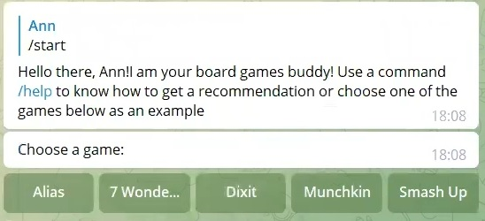

Для получения дополнительной информации, можно использовать команду /help

**Входные данные:** /help

**Выходные данные:** Бот отправляет информацию о том, как получить рекомендацию

**Скрин интерфейса:**

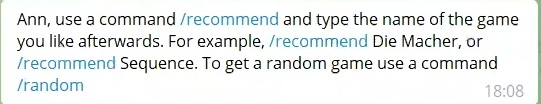

Для рекомендации игры пользователь либо выбирает игру из списка для примера, либо использует комманду /recommend. Например, /recommend Die Macher или /recommend Die_Macher - оба варианта принимаются системой.

**Выходные данные:** Бот отправляет рекомендации похожих игр и предлагает оставить отзыв о работе сервиса

**Скрин интерфейса:**

[figure not shown]

В случае если название введено неверно или игры нет в датасете, бот информирует об этом.

**Входные данные:** Пользователь вводит неверное название игры /recommend vvv

**Выходные данные:** Бот отправляет сообщение, что игра не найдена или название введено некорректно и предлагает попробовать еще раз

**Скрин интерфейса:**

[figure not shown]

Чтобы получить рекомендацию рандомной игры, пользователь вводит команду /random **Входные данные:** /random

**Выходные данные:** Бот рекомендует рандомную игру из датасета и выводит информацию про некоторые характеристики игры

**Скрин интерфейса:**

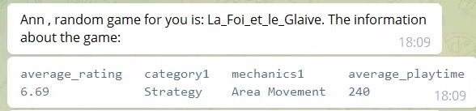

**Код интерфейса:**

```r
# здесь код только для интерфейса
library(telegram.bot)

# создаём экземпляр класса Updater
updater <- Updater('SECRETKEY')


# Пишем метод для приветсвия
## команда приветвия
start <- function(bot, update) {

  # Имя пользователя с которым надо поздароваться
    user_name <- update$message$from$first_name

  # Отправляем приветсвенное сообщение
    bot$sendMessage(update$message$chat_id,
                  text = paste0("Hello there, ", user_name, "!","I am your board games buddy! Use a command /help to know how to get a recommendation or choose one of the games below as an example"),
                                    reply_to_message_id = update$message$message_id)

     # создаём InLine клавиатуру
    IKM <- InlineKeyboardMarkup(
      inline_keyboard = list(
        list(
          InlineKeyboardButton("Alias", callback_data = 'Alias'),
          InlineKeyboardButton("7 Wonders", callback_data = '7_Wonders'),
          InlineKeyboardButton("Dixit", callback_data = 'Dixit'),
          InlineKeyboardButton("Munchkin", callback_data = 'Munchkin'),
          InlineKeyboardButton("Smash Up", callback_data = 'Smash_Up')


        )
      )
    )

    # Отправляем клавиатуру в чат
    bot$sendMessage(update$message$chat_id,
                    text = "Choose a game: ",
                    reply_markup = IKM)






  }

# создаём фильтры
MessageFilters$hi <- BaseFilter(function(message) {

  # проверяем, встречается ли в тексте сообщения слова: привет, здравствуй, салют, хай, бонжур
  grepl(x           = message$text,
        pattern     = 'привет|здравствуй|салют|хай|бонжур',
        ignore.case = TRUE)
  }
)

random <- function(bot, update) {


  user_name <- update$message$from$first_name
  out=recomendar(selectedgame, dissimilarity, board_games_rec,option ="random")

  info=get_info(out)

#redefine row and column names
  #rownames(info) <- colnames(info)
  #colnames(info) <- rownames(info)
  tg_table <- to_tg_table(as.data.frame(info))



  bot$sendMessage(update$message$chat_id,
                  text = paste0(user_name, " , random game for you is: ",out,". The information about the game:"),
                  parse_mode = "HTML")
  bot$sendMessage(update$message$chat_id,
                tg_table,
                "Markdown")
  bot$sendMessage(update$message$chat_id,
                  text =paste0("Please, give us feedback, how did you like our recommendation:  ","https://docs.google.com/forms/d/e/1FAIpQLScbLYpcw1fUr5FLbZcmCA5E5uXJj6xqyBCmqHfYdItpeIAmKw/viewform"))
}

recommend <- function(bot, update, args) {

  # входящие данные
  game     <- str_c(args, collapse="_")  # дата

  selectedgame <- user_input(game)
  user_name <- update$message$from$first_name
  if ( game %in% board_games_rec$name) {
    out = recomendar(selectedgame, dissimilarity, board_games_rec,option ="recommend")
    msg = paste(out$name, collapse = ", ")

    # отправляем сообщение
    bot$sendMessage(update$message$chat_id,
                  text = paste0(user_name, ", you indicated that you like ", game,". We recommend you to play: ", msg)
                 )
    bot$sendAnimation(update$message$chat_id,
    animation = "https://media.giphy.com/media/sIIhZliB2McAo/giphy.gif"
)
    bot$sendMessage(update$message$chat_id,
                  text =paste0("Please, give us feedback, how did you like our recommendation:  ","https://docs.google.com/forms/d/e/1FAIpQLScbLYpcw1fUr5FLbZcmCA5E5uXJj6xqyBCmqHfYdItpeIAmKw/viewform"))
  }

  else {
  # Send Custom Keyboard
    bot$sendMessage(update$message$chat_id,
    text = paste0(game, " - Perhaps the name of the game was entered incorrectly, or we do not have such a game"),
    parse_mode = "Markdown")

    bot$sendAnimation(update$message$chat_id,
    animation = "https://media4.giphy.com/media/CoND5j6Bn1QZUgm1xX/giphy.gif"
)

  }
}

help <- function(bot, update) {

  # Имя пользователя с которым надо поздароваться
  user_name <- update$message$from$first_name

  # Отправка приветственного сообщения
  bot$sendMessage(update$message$chat_id,
                  text = paste0(user_name, ", use a command /recommend and type the name of the game you like afterwards. For example, /recommend Die Macher, or /recommend Sequence. To get a random game use a command /random")
                  )

}



# метод для обработки нажатия кнопки Да
answer_cb_Alias <- function(bot, update) {

  # получаем имя пользователя, нажавшего кнопку
  uname <- update$effective_user()$first_name
  # обработка результата
  out = Alias
  msg = paste(out$name, collapse = ", ")

    # отправляем сообщение
  bot$sendMessage(chat_id = update$from_chat_id(),
                  text = paste0(uname, ", you indicated that you like ", "Alias",". We recommend you to play: ", msg)
                 )
  bot$sendAnimation(chat_id = update$from_chat_id(), animation = "https://media.giphy.com/media/sIIhZliB2McAo/giphy.gif")
  # Отправка сообщения


  # сообщаем боту, что запрос с кнопки принят
  bot$answerCallbackQuery(callback_query_id = update$callback_query$id)
}

# метод для обработки нажатия кнопки Нет
answer_cb_7_Wonders <- function(bot, update) {

   # получаем имя пользователя, нажавшего кнопку
  uname <- update$effective_user()$first_name
  # обработка результата
  out = sev_Wonders
  msg = paste(out$name, collapse = ", ")

    # отправляем сообщение
  bot$sendMessage(chat_id = update$from_chat_id(),
                  text = paste0(uname, ", you indicated that you like ", "7 Wonders",". We recommend you to play: ", msg)
                 )
  bot$sendAnimation(chat_id = update$from_chat_id(), animation = "https://media.giphy.com/media/sIIhZliB2McAo/giphy.gif")

  # сообщаем боту, что запрос с кнопки принят
  bot$answerCallbackQuery(callback_query_id = update$callback_query$id)
}

# метод для обработки нажатия кнопки Нет
answer_cb_Dixit <- function(bot, update) {

   # получаем имя пользователя, нажавшего кнопку
  uname <- update$effective_user()$first_name
  # обработка результата
  out = Dixit
  msg = paste(out$name, collapse = ", ")

    # отправляем сообщение
  bot$sendMessage(chat_id = update$from_chat_id(),
                  text = paste0(uname, ", you indicated that you like ", "Dixit",". We recommend you to play: ", msg)
                 )
  bot$sendAnimation(chat_id = update$from_chat_id(), animation = "https://media.giphy.com/media/sIIhZliB2McAo/giphy.gif")

  # сообщаем боту, что запрос с кнопки принят
  bot$answerCallbackQuery(callback_query_id = update$callback_query$id)
}


# метод для обработки нажатия кнопки Нет
answer_cb_Munchkin <- function(bot, update) {

   # получаем имя пользователя, нажавшего кнопку
  uname <- update$effective_user()$first_name
  # обработка результата
  out = Munchkin
  msg = paste(out$name, collapse = ", ")

    # отправляем сообщение
  bot$sendMessage(chat_id = update$from_chat_id(),
                  text = paste0(uname, ", you indicated that you like ", "Munchkin",". We recommend you to play: ", msg)
                 )
  bot$sendAnimation(chat_id = update$from_chat_id(), animation = "https://media.giphy.com/media/sIIhZliB2McAo/giphy.gif")

  # сообщаем боту, что запрос с кнопки принят
  bot$answerCallbackQuery(callback_query_id = update$callback_query$id)
}

# метод для обработки нажатия кнопки Нет
answer_cb_Smash_Up <- function(bot, update) {

   # получаем имя пользователя, нажавшего кнопку
  uname <- update$effective_user()$first_name
  # обработка результата
  out = Smash_Up
  msg = paste(out$name, collapse = ", ")

    # отправляем сообщение
  bot$sendMessage(chat_id = update$from_chat_id(),
                  text = paste0(uname, ", you indicated that you like ", "Smash Up",". We recommend you to play: ", msg)
                 )
  bot$sendAnimation(chat_id = update$from_chat_id(), animation = "https://media.giphy.com/media/sIIhZliB2McAo/giphy.gif")

  # сообщаем боту, что запрос с кнопки принят
  bot$answerCallbackQuery(callback_query_id = update$callback_query$id)
}

# создаём обработчики
inline_h          <- CommandHandler('start', start)
query_handler_Alias <- CallbackQueryHandler(answer_cb_Alias, pattern = 'Alias')
query_handler_7_Wonders  <- CallbackQueryHandler(answer_cb_7_Wonders, pattern = '7_Wonders')
query_handler_Dixit  <- CallbackQueryHandler(answer_cb_Dixit, pattern = 'Dixit')
query_handler_Munchkin  <- CallbackQueryHandler(answer_cb_Munchkin, pattern = 'Munchkin')
query_handler_Smash_Up  <- CallbackQueryHandler(answer_cb_Smash_Up, pattern = 'Smash_Up')

# создаём обработчик
#hi_hendler <- CommandHandler('start', say_hello) # обработчик команды hi
hi_txt_hnd <- MessageHandler(say_hello, filters = MessageFilters$hi)
help_hendler <- CommandHandler('help', help)
random_hendler <- CommandHandler('random', random)
date_hendler <- CommandHandler('recommend', recommend, pass_args = TRUE)
# добаляем обработчики в диспетчер
updater <- updater +
             hi_txt_hnd +
             help_hendler +
             random_hendler +
             date_hendler +
             inline_h +
             query_handler_Alias +
             query_handler_7_Wonders +
             query_handler_Dixit +
             query_handler_Munchkin +
             query_handler_Smash_Up


# запускаем бота
updater$start_polling()
```

### Оценивание / Выводы

Оценивание приложения производилось следующим образом. На стадии оценивания рекомендательной системы использовалась оценка на адекватность - то есть сами определяли, насколько рекомендация имеет место быть. Формальных численных метрик получить не удалось, однако рекомендации соответствовали ожидаемым результатам.

После разработки чат-бот был протестирован любителями настольных игр. Единственная проблема на этом этапе заключалась в том, что нет хостинга, из-за чего бота приходилось каждый раз включать. В результате люди положительно отзывались о рекомендациях, выданных ботом. Конечно, бота ещё необходимо развивать: например, сделать более интуитивно понятный интерфейс или же купить хостинг, однако в общем и целом с поставленными задачами бот справляется.

```r
#Приступим к оценке рекомендательной системы. Качество рекомендаций будет определяться с помощью проверки на адекватность.

#Введем игру под названием "Sequence" - стартегическая игра с механикой "hand management". В результатах ожидаются игры на составление комбинаций для детей от 7 лет.
selectedgame <- user_input("Sequence")

#Получим рекомендации по игре
recomendaciones = recomendar(selectedgame, dissimilarity, board_games_rec,option ="recommend")
recomendaciones
```

```
##                           name
## 3055                    CLEVER
## 4361           Pegs_and_Jokers
## 9026               Lugenbeutel
## 13507          All_My_Children
## 13565 Nosey_Neighbor_Card_Game
```

```r
#В целом, рекомендации проверку проходят: они все подходят для детей и не занимают много времени, как и Sequence. Но на рекомендациях сказывается то, что для системы использовалась только одна механика из четырех. Возможно, если добавить еще одну, рекомендуемые будут лучше совпадать с указанной игрой.

#Проведем еще одну оценку и предположим, чтопользователь обожает дипломатические игры, десять раз прошел Цивилизацию и теперь хочет найти еще несколько подобных шедевров. Ожидаем что-то времязатратное, на контроль территорий и историческое.
selectedgame <- user_input("Sid_Meier's_Civilization:_The_Board_Game")
recomendaciones = recomendar(selectedgame, dissimilarity, board_games_rec,option ="recommend")
recomendaciones
```

```
##                          name
## 225                   Village
## 6427               Kingdomino
## 9376                 Dominion
## 10022      Dominion:_Intrigue
## 10969 The_Princes_of_Florence
```

```r
#Та же проблема, что и с прошлым поиском: игры в целом подобраны неплохо, но большая часть из них вряд ли удовлетворят потребности теоретического пользователя-любителя Цивилизации.
```

```r
#Попробовали добавить еще одну категорию, чтобы повысить точность рекомендаций. Обновленные результаты выведены выше вместо предыдущих. В случае Sequence рекомендации практически не изменились. Вероятно, можно было бы добиться лучших рекомендаций для подобных Sequence игр, добавив еще одну механику, но это не вышло в силу их огромного разнообразия. В это же время подборка для любителя Цивилизации претерпела гораздо бОльшие изменения: в ней появилось больше исторических игр, игр про королевства. По механикам вышло не так схоже, но по категориям уже больше соответствует запросу, сложность и другие параметры также схожи, поэтому на этом остановимся.
```